# Lecture 17: Asymptotics

Economics 326 — Introduction to Econometrics II

Author

Vadim Marmer, UBC

Published

July 20, 2026

## Why we need large-sample theory

- The OLS estimator $\hat{\beta}$ has desirable properties:
  - $\hat{\beta}$ is unbiased if the errors are **strongly exogenous**: $\mathrm{E}\left[U_i \mid \mathbf{X}\right] =0.$
  - If in addition the errors are **homoskedastic**, then $\widehat{\mathrm{Var}}\left(\hat{\beta}\right)=s^{2}/\sum_{i=1}^{n}\left( X_{i}-\bar{X}\right) ^{2}$ is an unbiased estimator of the conditional variance of $\hat{\beta}$.
  - If in addition the errors are **normally** distributed (given $\mathbf{X}$), then $T=\left( \hat{\beta}-\beta \right) /\sqrt{\widehat{\mathrm{Var}}\left(\hat{\beta}\right)}$ has a $t$ distribution which can be used for hypothesis testing.

## Limitations of finite-sample theory

- If the errors are only **weakly exogenous**:
  $$\mathrm{E}\left[X_{i}U_{i}\right] =0,$$
  the OLS estimator is in general biased.
- If the errors are **heteroskedastic**:
  $$\mathrm{E}\left[U_{i}^{2} \mid X_{i}\right] =h\left( X_{i}\right),$$
  the “usual” variance formula is invalid; we also do not have an unbiased estimator for the variance in this case.
- If the errors are **not normally distributed** conditional on $\mathbf{X}$, then $T$- and $F$-statistics do not have $t$ and $F$ distributions under the null hypothesis.
- Asymptotic (large-sample) theory allows us to derive **approximate** properties and distributions of estimators and test statistics by assuming that the sample size $n$ is very large.

# Part I: Consistency

## Convergence of a sequence

- A sequence of real numbers $a_{1}, a_{2}, \ldots$ **converges** to $a$ if for every $\varepsilon > 0$ there exists $N$ such that $|a_{n} - a| < \varepsilon$ for all $n \geq N$. We write $a_{n} \to a$.

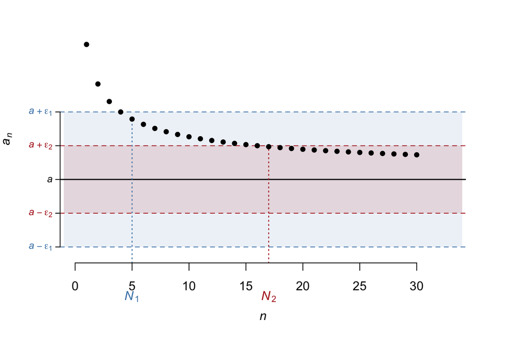

  Since $\varepsilon_{1} > \varepsilon_{2}$, the $\varepsilon_{2}$-band is narrower, so it takes more terms for the sequence to stay inside it: $N_{2} > N_{1}$. Smaller $\varepsilon$ requires larger $N$.
- A sequence that **does not converge**: $a_{n} = a + c\sin(n)$ oscillates indefinitely around $a$.

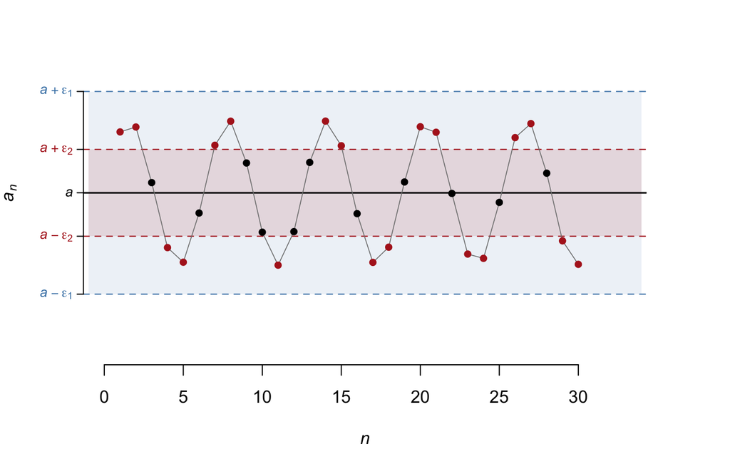

  For $\varepsilon_{1} > c$, all terms lie within the $\varepsilon_{1}$-band. But for $\varepsilon_{2} < c$, terms keep falling outside the $\varepsilon_{2}$-band (red dots) no matter how far along the sequence we go. Convergence requires the condition to hold for **all** $\varepsilon > 0$, so the sequence does not converge.
- Our estimator $\hat{\beta}_{n}$ is **random**: its value changes with each sample. To apply the concept of convergence, we need to convert it into a **non-random** sequence indexed by $n$.
- We take $a_{n} = P\left(\left\vert \hat{\beta}_{n}-\beta \right\vert \geq \varepsilon \right)$, which is a non-random number for each $n$. We say $\hat{\beta}_{n}$ **converges in probability** to $\beta$ if $a_{n} \to 0$ for all $\varepsilon > 0$.

## Convergence in probability and LLN

- More generally, let $\theta _{n}$ be a sequence of random variables indexed by the sample size $n.$ We say that $\theta _{n}$ **converges in probability** to $\theta$ if
  $$\lim_{n\rightarrow \infty }P\left( \left\vert \theta _{n}-\theta \right\vert \geq \varepsilon \right) =0\text{ for all }\varepsilon >0.$$
- We denote this as $\theta _{n}\rightarrow _{p}\theta$ or $p\lim \theta _{n}=\theta.$
- An example of convergence in probability is a Law of Large Numbers (LLN):

  Let $X_{1},X_{2},\ldots ,X_{n}$ be a random sample such that $\mathrm{E}\left[X_{i}\right] =\mu$ for all $i=1,\ldots ,n,$ and define $\bar{X}_{n}=\frac{1}{n}\sum_{i=1}^{n}X_{i}.$ Then, under certain conditions,
  $$\bar{X}_{n}\rightarrow _{p}\mu.$$

## LLN

- Let $X_{1},\ldots ,X_{n}$ be a sample of **independent identically distributed** (**iid**) random variables. Let $\mathrm{E}\left[X_{i}\right]=\mu$. If $\mathrm{Var}\left(X_{i}\right)=\sigma ^{2}<\infty$, then
  $$\bar{X}_{n}\rightarrow _{p}\mu.$$
- In fact when the data are **iid**, the LLN holds if
  $$\mathrm{E}\left[\left\vert X_{i}\right\vert\right] <\infty,$$
  but we prove the result under a stronger assumption that $\mathrm{Var}\left(X_{i}\right)<\infty.$

## Markov’s inequality

- **Markov’s inequality.** Let $W$ be a random variable. For $\varepsilon >0$ and $r>0$,
  $$P\left( \left\vert W\right\vert \geq \varepsilon \right) \leq \frac{\mathrm{E}\left[\left\vert W\right\vert ^{r}\right]}{\varepsilon ^{r}}.$$
- With $r=2,$ we have **Chebyshev’s inequality**. Suppose that $\mathrm{E}\left[X\right]=\mu.$ Take $W\equiv X-\mu$ and apply Markov’s inequality with $r=2$. For $\varepsilon >0,$

  $$\begin{aligned}
  P\left( \left\vert X-\mu \right\vert \geq \varepsilon \right) &\leq \frac{\mathrm{E}\left[\left\vert X-\mu \right\vert ^{2}\right]}{\varepsilon ^{2}} \\
  &= \frac{\mathrm{Var}\left(X\right)}{\varepsilon ^{2}}.
  \end{aligned}$$
- The probability of observing an outlier (a large deviation of $X$ from its mean $\mu$) can be bounded by the variance.

## Proof of Markov’s inequality

- For any event $A$, the expectation of its indicator equals the probability of the event:
  $$\mathrm{E}\left[\mathbf{1}(A)\right] = 1 \cdot P(A) + 0 \cdot P(A^c) = P(A).$$
- Define the indicator $\mathbf{1}\left(\left\vert W \right\vert \geq \varepsilon\right)$, which equals $1$ when $\left\vert W \right\vert \geq \varepsilon$ and $0$ otherwise. Then:

$$\begin{aligned}
&\mathbf{1}\left(\left\vert W \right\vert \geq \varepsilon\right)\\
&\fragment{{}\quad= \mathbf{1}\left(\left\vert W \right\vert^r \geq \varepsilon^r\right)} \\
&\fragment{{}\quad= \mathbf{1}\!\left(\frac{\left\vert W \right\vert^r}{\varepsilon^r} \geq 1\right)} \\
&\fragment{{}\quad\leq \frac{\left\vert W \right\vert^r}{\varepsilon^r}} \\
&\fragment{{}\Longrightarrow }\\
&\fragment{{} P\left(\left\vert W \right\vert \geq \varepsilon\right)
= \mathrm{E}\left[\mathbf{1}\left(\left\vert W \right\vert \geq \varepsilon\right)\right]
\leq \frac{\mathrm{E}\left[\left\vert W \right\vert^r\right]}{\varepsilon^r}.}
\end{aligned}$$

## Proof of the LLN

- Fix $\varepsilon >0$ and apply Markov’s inequality with $r=2:$

$$\begin{aligned}
P\left( \left\vert \bar{X}_{n}-\mu \right\vert \geq \varepsilon \right)
&\fragment{{}= P\left( \left\vert \frac{1}{n}\sum_{i=1}^{n}X_{i}-\mu \right\vert \geq \varepsilon \right)} \\
&\fragment{{}= P\left( \left\vert \frac{1}{n}\sum_{i=1}^{n}\left( X_{i}-\mu \right) \right\vert \geq \varepsilon \right)} \\
&\fragment{{}\leq \frac{\mathrm{E}\left[\left( \frac{1}{n}\sum_{i=1}^{n}\left( X_{i}-\mu \right) \right) ^{2}\right]}{\varepsilon ^{2}}} \\
&\fragment{{}= \frac{1}{n^{2}\varepsilon ^{2}}\left( \sum_{i=1}^{n}\mathrm{E}\left[\left( X_{i}-\mu \right) ^{2}\right]+\sum_{i=1}^{n}\sum_{j\neq i}\mathrm{E}\left[\left( X_{i}-\mu \right) \left( X_{j}-\mu \right)\right] \right)} \\
&\fragment{{}= \frac{1}{n^{2}\varepsilon ^{2}}\left( \sum_{i=1}^{n}\mathrm{Var}\left(X_{i}\right)+\sum_{i=1}^{n}\sum_{j\neq i}\mathrm{Cov}\left(X_{i},X_{j}\right)\right)} \\
&\fragment{{}= \frac{n\sigma ^{2}}{n^{2}\varepsilon ^{2}} = \frac{\sigma ^{2}}{n\varepsilon ^{2}} \rightarrow 0 \text{ as }n\rightarrow \infty \text{ for all }\varepsilon >0.}
\end{aligned}$$

## Averaging and variance reduction

- Let $X_{1},\ldots ,X_{n}$ be a sample and suppose that

  $$\begin{aligned}
  \mathrm{E}\left[X_{i}\right] &= \mu \text{ for all }i=1,\ldots ,n, \\
  \mathrm{Var}\left(X_{i}\right) &= \sigma ^{2}\text{ for all }i=1,\ldots ,n, \\
  \mathrm{Cov}\left(X_{i},X_{j}\right) &= 0\text{ for all }j\neq i.
  \end{aligned}$$
- The mean of the sample average:

  $$\begin{aligned}
  \mathrm{E}\left[\bar{X}_{n}\right] &= \mathrm{E}\left[\frac{1}{n}\sum_{i=1}^{n}X_{i}\right] \\
  &= \frac{1}{n}\sum_{i=1}^{n}\mathrm{E}\left[X_{i}\right] \\
  &= \frac{1}{n}\sum_{i=1}^{n}\mu = \frac{1}{n}n\mu =\mu.
  \end{aligned}$$

## Variance of the sample average

- The variance of the sample average:

  $$\begin{aligned}
  \mathrm{Var}\left(\bar{X}_{n}\right) &= \mathrm{Var}\left(\frac{1}{n}\sum_{i=1}^{n}X_{i}\right) \\
  &= \frac{1}{n^{2}}\mathrm{Var}\left(\sum_{i=1}^{n}X_{i}\right) \\
  &= \frac{1}{n^{2}}\left( \sum_{i=1}^{n}\mathrm{Var}\left(X_{i}\right)+\sum_{i=1}^{n}\sum_{j\neq i}\mathrm{Cov}\left(X_{i},X_{j}\right)\right) \\
  &= \frac{1}{n^{2}}\left( \sum_{i=1}^{n}\sigma ^{2}+\sum_{i=1}^{n}\sum_{j\neq i}0\right) \\
  &= \frac{1}{n^{2}}n\sigma ^{2}=\frac{\sigma ^{2}}{n}.
  \end{aligned}$$
- The variance of the average approaches zero as $n\rightarrow \infty$ if the observations are **uncorrelated**.

## Convergence in probability: properties

- **Slutsky’s Lemma.** Suppose that $\theta _{n}\rightarrow _{p}\theta,$ and let $g$ be a function continuous at $\theta.$ Then,
  $$g\left( \theta _{n}\right) \rightarrow _{p}g\left( \theta \right).$$
  - If $\theta _{n}\rightarrow _{p}\theta,$ then $\theta _{n}^{2}\rightarrow _{p}\theta ^{2}.$
  - If $\theta _{n}\rightarrow _{p}\theta$ and $\theta \neq 0,$ then $1/\theta _{n}\rightarrow _{p}1/\theta.$
- Suppose that $\theta _{n}\rightarrow _{p}\theta$ and $\lambda _{n}\rightarrow _{p}\lambda.$ Then,
  - $\theta _{n}+\lambda _{n}\rightarrow _{p}\theta +\lambda.$
  - $\theta _{n}\lambda _{n}\rightarrow _{p}\theta \lambda.$
  - $\theta _{n}/\lambda _{n}\rightarrow _{p}\theta /\lambda$ provided that $\lambda \neq 0.$

## Consistency

- Let $\hat{\beta}_{n}$ be an estimator of $\beta$ based on a sample of size $n.$
- We say that $\hat{\beta}_{n}$ is a **consistent** estimator of $\beta$ if as $n\rightarrow \infty,$
  $$\hat{\beta}_{n}\rightarrow _{p}\beta.$$
- Consistency means that the **probability** of the event that the distance between $\hat{\beta}_{n}$ and $\beta$ exceeds $\varepsilon >0$ can be made arbitrarily small by increasing the sample size.

## Consistency of OLS

- Suppose that:
  1. The data $\left\{ \left( Y_{i},X_{i}\right) :i=1,\ldots ,n\right\}$ are iid.
  2. $Y_{i}=\beta _{0}+\beta _{1}X_{i}+U_{i},$ where $\mathrm{E}\left[U_{i}\right] =0.$
  3. $\mathrm{E}\left[X_{i}U_{i}\right] =0.$
  4. $0<\mathrm{Var}\left(X_{i}\right)<\infty.$
- Let $\hat{\beta}_{0,n}$ and $\hat{\beta}_{1,n}$ be the OLS estimators of $\beta _{0}$ and $\beta _{1}$ based on a sample of size $n$. Under Assumptions 1–4,
  $$\begin{aligned}
  \hat{\beta}_{0,n} &\rightarrow _{p}\beta _{0}, \\
  \hat{\beta}_{1,n} &\rightarrow _{p}\beta _{1}.
  \end{aligned}$$
- The key identifying assumption is Assumption 3: $\mathrm{Cov}\left(X_{i},U_{i}\right)=0.$

## Proof of consistency

- Write

  $$\begin{aligned}
  \hat{\beta}_{1,n} = \frac{\sum_{i=1}^{n}\left( X_{i}-\bar{X}_{n}\right) Y_{i}}{\sum_{i=1}^{n}\left( X_{i}-\bar{X}_{n}\right) ^{2}}
  &= \beta _{1}+\frac{\sum_{i=1}^{n}\left( X_{i}-\bar{X}_{n}\right) U_{i}}{\sum_{i=1}^{n}\left( X_{i}-\bar{X}_{n}\right) ^{2}} \\
  &= \beta _{1}+\frac{\frac{1}{n}\sum_{i=1}^{n}\left( X_{i}-\bar{X}_{n}\right) U_{i}}{\frac{1}{n}\sum_{i=1}^{n}\left( X_{i}-\bar{X}_{n}\right) ^{2}}.
  \end{aligned}$$
- We will show that
  $$\begin{aligned}
  \frac{1}{n}\sum_{i=1}^{n}\left( X_{i}-\bar{X}_{n}\right) U_{i} &\rightarrow _{p}0, \\
  \frac{1}{n}\sum_{i=1}^{n}\left( X_{i}-\bar{X}_{n}\right) ^{2} &\rightarrow _{p}\mathrm{Var}\left(X_{i}\right),
  \end{aligned}$$
- Since $\mathrm{Var}\left(X_{i}\right)\neq 0,$
  $$\hat{\beta}_{1,n} = \beta _{1}+\frac{\frac{1}{n}\sum_{i=1}^{n}\left( X_{i}-\bar{X}_{n}\right) U_{i}}{\frac{1}{n}\sum_{i=1}^{n}\left( X_{i}-\bar{X}_{n}\right) ^{2}} \rightarrow _{p} \beta _{1}+\frac{0}{\mathrm{Var}\left(X_{i}\right)}= \beta _{1}.$$

## Numerator converges to zero

$$\frac{1}{n}\sum_{i=1}^{n}\left( X_{i}-\bar{X}_{n}\right) U_{i} = \frac{1}{n}\sum_{i=1}^{n}X_{i}U_{i}-\bar{X}_{n}\left( \frac{1}{n}\sum_{i=1}^{n}U_{i}\right).$$

By the LLN,

$$\begin{aligned}
\frac{1}{n}\sum_{i=1}^{n}X_{i}U_{i} &\rightarrow _{p}\mathrm{E}\left[X_{i}U_{i}\right] =0, \\
\bar{X}_{n} &\rightarrow _{p}\mathrm{E}\left[X_{i}\right], \\
\frac{1}{n}\sum_{i=1}^{n}U_{i} &\rightarrow _{p}\mathrm{E}\left[U_{i}\right] =0.
\end{aligned}$$

Hence,

$$\begin{aligned}
\frac{1}{n}\sum_{i=1}^{n}\left( X_{i}-\bar{X}_{n}\right) U_{i} &= \frac{1}{n}\sum_{i=1}^{n}X_{i}U_{i}-\bar{X}_{n}\left( \frac{1}{n}\sum_{i=1}^{n}U_{i}\right) \\
&\rightarrow _{p}0-\mathrm{E}\left[X_{i}\right] \cdot 0 = 0.
\end{aligned}$$

## Denominator converges to $\mathrm{Var}\left(X_i\right)$

- The sample variance can be written as
  $$\frac{1}{n}\sum_{i=1}^{n}\left( X_{i}-\bar{X}_{n}\right) ^{2} = \frac{1}{n}\sum_{i=1}^{n}X_{i}^{2}-\bar{X}_{n}^{2}.$$
- By the LLN, $\frac{1}{n}\sum_{i=1}^{n}X_{i}^{2}\rightarrow _{p}\mathrm{E}\left[X_{i}^{2}\right]$ and $\bar{X}_{n}\rightarrow _{p}\mathrm{E}\left[X_{i}\right].$
- By Slutsky’s Lemma, $\bar{X}_{n}^{2}\rightarrow _{p}\left( \mathrm{E}\left[X_{i}\right]\right) ^{2}.$
- Thus,
  $$\frac{1}{n}\sum_{i=1}^{n}\left( X_{i}-\bar{X}_{n}\right) ^{2}=\frac{1}{n}\sum_{i=1}^{n}X_{i}^{2}-\bar{X}_{n}^{2}\rightarrow _{p}\mathrm{E}\left[X_{i}^{2}\right] -\left( \mathrm{E}\left[X_{i}\right]\right) ^{2}=\mathrm{Var}\left(X_{i}\right).$$

## Multiple regression

- Under similar conditions to 1–4, one can establish consistency of OLS for the multiple linear regression model:
  $$Y_{i}=\beta _{0}+\beta _{1}X_{1,i}+\ldots +\beta _{k}X_{k,i}+U_{i},$$
  where $\mathrm{E}\left[U_{i}\right]=0.$
- The key assumption is that the errors and regressors are uncorrelated:
  $$\mathrm{E}\left[X_{1,i}U_{i}\right] =\ldots =\mathrm{E}\left[X_{k,i}U_{i}\right] =0.$$

## Omitted variables and OLS inconsistency

- Suppose that the true model has two regressors:
  $$\begin{aligned}
  &Y_{i}=\beta _{0}+\beta _{1}X_{1,i}+\beta _{2}X_{2,i}+U_{i}, \\
  &\mathrm{E}\left[X_{1,i}U_{i}\right] =\mathrm{E}\left[X_{2,i}U_{i}\right] =0.
  \end{aligned}$$
- Suppose that the econometrician includes **only** $X_{1}$ in the regression when estimating $\beta _{1}$:

  $$\begin{aligned}
  \tilde{\beta}_{1,n} &= \frac{\sum_{i=1}^{n}\left( X_{1,i}-\bar{X}_{1,n}\right) Y_{i}}{\sum_{i=1}^{n}\left( X_{1,i}-\bar{X}_{1,n}\right) ^{2}} \\
  &= \frac{\sum_{i=1}^{n}\left( X_{1,i}-\bar{X}_{1,n}\right) \left( \beta _{0}+\beta _{1}X_{1,i}+\beta _{2}X_{2,i}+U_{i}\right) }{\sum_{i=1}^{n}\left( X_{1,i}-\bar{X}_{1,n}\right) ^{2}} \\
  &= \beta _{1}+\beta _{2}\frac{\sum_{i=1}^{n}\left( X_{1,i}-\bar{X}_{1,n}\right) X_{2,i}}{\sum_{i=1}^{n}\left( X_{1,i}-\bar{X}_{1,n}\right) ^{2}} \\
  &\quad +\frac{\sum_{i=1}^{n}\left( X_{1,i}-\bar{X}_{1,n}\right) U_{i}}{\sum_{i=1}^{n}\left( X_{1,i}-\bar{X}_{1,n}\right) ^{2}}.
  \end{aligned}$$
- Dividing numerator and denominator by $n$ and applying the LLN as before:
  - The noise term vanishes:
    $$\frac{\frac{1}{n}\sum_{i=1}^{n}\left( X_{1,i}-\bar{X}_{1,n}\right) U_{i}}{\frac{1}{n}\sum_{i=1}^{n}\left( X_{1,i}-\bar{X}_{1,n}\right) ^{2}} \rightarrow _{p} \frac{\mathrm{Cov}\left(X_{1,i},U_{i}\right)}{\mathrm{Var}\left(X_{1,i}\right)} = 0.$$
  - The bias term converges:
    $$\frac{\frac{1}{n}\sum_{i=1}^{n}\left( X_{1,i}-\bar{X}_{1,n}\right) X_{2,i}}{\frac{1}{n}\sum_{i=1}^{n}\left( X_{1,i}-\bar{X}_{1,n}\right) ^{2}} \rightarrow _{p} \frac{\mathrm{Cov}\left(X_{1,i},X_{2,i}\right)}{\mathrm{Var}\left(X_{1,i}\right)}.$$
- Therefore,
  $$\tilde{\beta}_{1,n} \rightarrow _{p} \beta _{1}+\beta _{2}\frac{\mathrm{Cov}\left(X_{1,i},X_{2,i}\right)}{\mathrm{Var}\left(X_{1,i}\right)}.$$
- $\tilde{\beta}_{1,n}$ is **inconsistent** unless:
  1. $\beta _{2}=0$ (the model is correctly specified).
  2. $\mathrm{Cov}\left(X_{1,i},X_{2,i}\right)=0$ (the omitted variable is **uncorrelated** with the included regressor).

## OVB through the composite error

- In this example, the model contains two regressors:
  $$\begin{aligned}
  &Y_{i}=\beta _{0}+\beta _{1}X_{1,i}+\beta _{2}X_{2,i}+U_{i}, \\
  &\mathrm{E}\left[X_{1,i}U_{i}\right] =\mathrm{E}\left[X_{2,i}U_{i}\right] =0.
  \end{aligned}$$
- However, since $X_{2}$ is not controlled for, it goes into the error term:
  $$\begin{aligned}
  Y_{i} &= \beta _{0}+\beta _{1}X_{1,i}+V_{i},\text{ where} \\
  V_{i} &= \beta _{2}X_{2,i}+U_{i}.
  \end{aligned}$$
- For consistency of $\tilde{\beta}_{1,n}$ we need $\mathrm{Cov}\left(X_{1,i},V_{i}\right) = 0$; however,

  $$\begin{aligned}
  \mathrm{Cov}\left(X_{1,i},V_{i}\right) &= \mathrm{Cov}\left(X_{1,i},\beta _{2}X_{2,i}+U_{i}\right) \\
  &= \mathrm{Cov}\left(X_{1,i},\beta _{2}X_{2,i}\right)+\mathrm{Cov}\left(X_{1,i},U_{i}\right) \\
  &= \beta _{2}\mathrm{Cov}\left(X_{1,i},X_{2,i}\right)+0 \\
  &\neq 0\text{, unless }\beta _{2}=0\text{ or }\mathrm{Cov}\left(X_{1,i},X_{2,i}\right)=0.
  \end{aligned}$$

# Part II: Asymptotic Normality

## Why do we need asymptotic normality?

- In the previous lectures, we showed that the OLS estimator has an **exact** normal distribution when the **errors are normally distributed**.
  - The same assumption is needed to show that the $T$ statistic has a $t$-distribution and the $F$ statistic has an $F$-distribution.
- In this lecture, we argue that even when the errors are **not** normally distributed, the OLS estimator has an **approximately normal distribution** in large samples, provided that some additional conditions hold.
  - This property is used for hypothesis testing: in large samples, the $T$ statistic has a standard normal distribution and the $F$ statistic has a $\chi^{2}$ distribution (approximately).

## Asymptotic normality

- Let $W_{n}$ be a sequence of random variables indexed by the sample size $n.$
  - Typically, $W_{n}$ will be a function of some estimator, such as $W_{n}=\sqrt{n}\left( \hat{\beta}_{n}-\beta \right)$.
- We say that $W_{n}$ has an **asymptotically** normal distribution if its **CDF** converges to a **normal CDF**.
- Let $W$ be any random variable with a normal $N\left( 0,\sigma^{2}\right)$ distribution and let $F$ denote its CDF. We say that $W_{n}$ has an asymptotically normal distribution if for all $x\in \mathbb{R}$:

  $$F_{n}\left( x\right) =P\left( W_{n}\leq x\right) \rightarrow P\left( W\leq x\right) =F\left( x\right) \text{ as }n\rightarrow \infty .$$
  - We denote this as $W_{n}\rightarrow _{d}W$ or $W_{n}\rightarrow _{d}N\left( 0,\sigma ^{2}\right).$

## Convergence in distribution

- Asymptotic normality is an example of convergence in distribution.
- We say that a sequence of random variables $W_{n}$ converges in distribution to $W$ (denoted as $W_{n}\rightarrow _{d}W$) if the CDF of $W_{n}$ converges to the CDF of $W$ at all points where the CDF of $W$ is continuous.
- Convergence in distribution is convergence of the **CDFs**.

## Central Limit Theorem (CLT)

- An example of convergence in distribution is a CLT.
- Let $X_{1},\ldots ,X_{n}$ be a sample of **iid** random variables such that $\mathrm{E}\left[X_{i}\right] =0$ and $\mathrm{Var}\left(X_{i}\right) =\sigma ^{2}>0$ (finite). Then, as $n\rightarrow \infty,$

  $$\frac{1}{\sqrt{n}}\sum_{i=1}^{n}X_{i}\rightarrow _{d}N\left( 0,\sigma^{2}\right) .$$
- $\rightarrow_{d}$ means that the CDF of the scaled sum converges to the normal CDF: for every $x$,
  $$P\left(\frac{1}{\sigma\sqrt{n}}\sum_{i=1}^{n}X_{i} \leq x\right) \rightarrow \Phi(x) \text{ as } n \rightarrow \infty,$$
  where $\Phi$ is the standard normal CDF. For large $n$, the distribution of the scaled sum is approximately normal.

## CLT with non-zero mean

- For the CLT we impose 3 assumptions: **(1)** iid; **(2)** Mean zero; **(3)** Finite variance different from zero.
- If $X_{1},\ldots ,X_{n}$ are iid but $\mathrm{E}\left[X_{i}\right] =\mu \neq 0,$ then consider $X_{i}-\mu.$ Since $\mathrm{E}\left[X_{i}-\mu\right] =0,$ we have

  $$\frac{1}{\sqrt{n}}\sum_{i=1}^{n}\left( X_{i}-\mu \right) \rightarrow_{d}N\left( 0,\mathrm{Var}\left(X_{i}\right) \right) .$$

  Then

  $$\begin{aligned}
  \frac{1}{\sqrt{n}}\sum_{i=1}^{n}\left( X_{i}-\mu \right) &= \sqrt{n}\frac{1}{n}\sum_{i=1}^{n}\left( X_{i}-\mu \right) \\
  &= \sqrt{n}\left( \frac{1}{n}\sum_{i=1}^{n}X_{i}-\frac{1}{n}\sum_{i=1}^{n}\mu \right) \\
  &= \sqrt{n}\left( \bar{X}_{n}-\mu \right) .
  \end{aligned}$$

## CLT for the sample average

- From the previous slide:
  $$\frac{1}{\sqrt{n}}\sum_{i=1}^{n}\left( X_{i}-\mu \right) = \sqrt{n}\left( \bar{X}_{n}-\mu \right) .$$
- Thus, the CLT can be stated as

  $$\sqrt{n}\left( \bar{X}_{n}-\mu \right) \rightarrow _{d}N\left( 0,\mathrm{Var}\left(X_{i}\right) \right) .$$
- By the LLN,

  $$\bar{X}_{n}-\mu \rightarrow _{p}0,$$

  and

  $$\mathrm{Var}\left(\sqrt{n}\left( \bar{X}_{n}-\mu \right)\right) = n\mathrm{Var}\left(\bar{X}_{n}\right) = n\frac{\mathrm{Var}\left(X_{i}\right)}{n} = \mathrm{Var}\left(X_{i}\right).$$

## Properties

- Suppose that $W_{n}\rightarrow _{d}N\left( 0,\sigma ^{2}\right)$ and $\theta _{n}\rightarrow _{p}\theta.$ Then,

  $$\theta _{n}W_{n}\rightarrow _{d}\theta N\left( 0,\sigma ^{2}\right) \stackrel{d}{=} N\left( 0,\theta ^{2}\sigma ^{2}\right) ,$$

  and

  $$\theta _{n}+W_{n}\rightarrow _{d}\theta +N\left( 0,\sigma ^{2}\right) \stackrel{d}{=} N\left( \theta ,\sigma ^{2}\right) .$$
- Suppose that $Z_{n}\rightarrow _{d}Z\sim N\left( 0,1\right).$ Then,

  $$Z_{n}^{2}\rightarrow _{d}Z^{2}\equiv \chi _{1}^{2}.$$
- If $W_{n}\rightarrow _{d}c=$ constant, then $W_{n}\rightarrow _{p}c.$

## Asymptotic normality of OLS

- Suppose that:
  1. The data $\left\{ \left( Y_{i},X_{i}\right) :i=1,\ldots ,n\right\}$ are iid.
  2. $Y_{i}=\beta _{0}+\beta _{1}X_{i}+U_{i},$ where $\mathrm{E}\left[U_{i}\right] =0.$
  3. $\mathrm{E}\left[X_{i}U_{i}\right] =0.$
  4. $0<\mathrm{Var}\left(X_{i}\right) <\infty.$
  5. $0<\mathrm{E}\left[\left( X_{i}-\mathrm{E}\left[X_{i}\right]\right) ^{2}U_{i}^{2}\right] <\infty$ and $0<\mathrm{E}\left[U_{i}^{2}\right] <\infty.$
- Let $\hat{\beta}_{1,n}$ be the OLS estimator of $\beta _{1}.$ Then,

  $$\sqrt{n}\left( \hat{\beta}_{1,n}-\beta _{1}\right) \rightarrow _{d}N\left( 0,\frac{\mathrm{E}\left[\left( X_{i}-\mathrm{E}\left[X_{i}\right]\right) ^{2}U_{i}^{2}\right]}{\left(\mathrm{Var}\left(X_{i}\right) \right) ^{2}}\right).$$
- $V=\dfrac{\mathrm{E}\left[\left( X_{i}-\mathrm{E}\left[X_{i}\right]\right) ^{2}U_{i}^{2}\right]}{\left(\mathrm{Var}\left(X_{i}\right) \right) ^{2}}$ is called the **asymptotic variance** of $\hat{\beta}_{1,n}.$

## Large-sample approximation for OLS

- Let $\overset{a}{\sim}$ denote “approximately in large samples.”
- The asymptotic normality

  $$\sqrt{n}\left( \hat{\beta}_{1,n}-\beta _{1}\right) \rightarrow _{d}N\left(0,V\right)$$

  can be viewed as the following large-sample **approximation**:

  $$\sqrt{n}\left( \hat{\beta}_{1,n}-\beta _{1}\right) \overset{a}{\sim} N\left(0,V\right) ,$$

  or

  $$\hat{\beta}_{1,n}\overset{a}{\sim} N\left( \beta _{1},V/n\right) .$$

## Proof: decomposition

Write

$$\hat{\beta}_{1,n}=\beta _{1}+\frac{\sum_{i=1}^{n}\left( X_{i}-\bar{X}_{n}\right) U_{i}}{\sum_{i=1}^{n}\left( X_{i}-\bar{X}_{n}\right) ^{2}}.$$

Now

$$\hat{\beta}_{1,n}-\beta _{1}=\frac{\frac{1}{n}\sum_{i=1}^{n}\left( X_{i}-\bar{X}_{n}\right) U_{i}}{\frac{1}{n}\sum_{i=1}^{n}\left( X_{i}-\bar{X}_{n}\right) ^{2}},$$

and

$$\sqrt{n}\left( \hat{\beta}_{1,n}-\beta _{1}\right) =\frac{\frac{1}{\sqrt{n}}\sum_{i=1}^{n}\left( X_{i}-\bar{X}_{n}\right) U_{i}}{\frac{1}{n}\sum_{i=1}^{n}\left( X_{i}-\bar{X}_{n}\right) ^{2}}.$$

## Proof: combining the limits

$$\sqrt{n}\left( \hat{\beta}_{1,n}-\beta _{1}\right) =\frac{\frac{1}{\sqrt{n}}\sum_{i=1}^{n}\left( X_{i}-\bar{X}_{n}\right) U_{i}}{\frac{1}{n}\sum_{i=1}^{n}\left( X_{i}-\bar{X}_{n}\right) ^{2}}.$$

In Part I, we established

$$\frac{1}{n}\sum_{i=1}^{n}\left( X_{i}-\bar{X}_{n}\right) ^{2}\rightarrow_{p}\mathrm{Var}\left(X_{i}\right).$$

We will show that

$$\frac{1}{\sqrt{n}}\sum_{i=1}^{n}\left( X_{i}-\bar{X}_{n}\right) U_{i}\rightarrow _{d}N\left( 0,\mathrm{E}\left[\left( X_{i}-\mathrm{E}\left[X_{i}\right]\right)^{2}U_{i}^{2}\right] \right),$$

so that

$$\begin{align*}
\sqrt{n}\left( \hat{\beta}_{1,n}-\beta _{1}\right) &= \frac{\frac{1}{\sqrt{n}}\sum_{i=1}^{n}\left( X_{i}-\bar{X}_{n}\right) U_{i}}{\frac{1}{n}\sum_{i=1}^{n}\left( X_{i}-\bar{X}_{n}\right) ^{2}} \\
&\rightarrow _{d}\frac{N\left( 0,\mathrm{E}\left[\left( X_{i}-\mathrm{E}\left[X_{i}\right]\right) ^{2}U_{i}^{2}\right] \right)}{\mathrm{Var}\left(X_{i}\right)} \\
&\stackrel{d}{=} N\left( 0,\frac{\mathrm{E}\left[\left( X_{i}-\mathrm{E}\left[X_{i}\right]\right)^{2}U_{i}^{2}\right]}{\left(\mathrm{Var}\left(X_{i}\right) \right) ^{2}}\right).
\end{align*}$$

## Proof: numerator CLT

$$\begin{aligned}
\frac{1}{\sqrt{n}}\sum_{i=1}^{n}\left( X_{i}-\bar{X}_{n}\right) U_{i} &= \frac{1}{\sqrt{n}}\sum_{i=1}^{n}\left( X_{i}-\mathrm{E}\left[X_{i}\right]+\mathrm{E}\left[X_{i}\right]-\bar{X}_{n}\right) U_{i} \\
&= \frac{1}{\sqrt{n}}\sum_{i=1}^{n}\left( X_{i}-\mathrm{E}\left[X_{i}\right]\right) U_{i}+\left( \mathrm{E}\left[X_{i}\right]-\bar{X}_{n}\right) \frac{1}{\sqrt{n}}\sum_{i=1}^{n}U_{i}.
\end{aligned}$$

We have

$$\mathrm{E}\left[\left( X_{i}-\mathrm{E}\left[X_{i}\right]\right) U_{i}\right] = \mathrm{E}\left[X_{i}U_{i}\right]-\mathrm{E}\left[X_{i}\right]\mathrm{E}\left[U_{i}\right]=0,$$

and $0<\mathrm{E}\left[\left( X_{i}-\mathrm{E}\left[X_{i}\right]\right) ^{2}U_{i}^{2}\right] <\infty,$ so by the CLT,

$$\frac{1}{\sqrt{n}}\sum_{i=1}^{n}\left( X_{i}-\mathrm{E}\left[X_{i}\right]\right) U_{i}\rightarrow_{d}N\left( 0,\mathrm{E}\left[\left( X_{i}-\mathrm{E}\left[X_{i}\right]\right) ^{2}U_{i}^{2}\right]\right).$$

## Proof: second term vanishes

It is left to show that

$$\left( \mathrm{E}\left[X_{i}\right]-\bar{X}_{n}\right) \frac{1}{\sqrt{n}}\sum_{i=1}^{n}U_{i}\rightarrow _{p}0.$$

We have $\mathrm{E}\left[U_{i}\right]=0$ and $0<\mathrm{E}\left[U_{i}^{2}\right]<\infty.$ By the CLT,

$$\frac{1}{\sqrt{n}}\sum_{i=1}^{n}U_{i}\rightarrow _{d}N\left(0,\mathrm{E}\left[U_{i}^{2}\right]\right).$$

By the LLN,

$$\mathrm{E}\left[X_{i}\right]-\bar{X}_{n}\rightarrow _{p}0.$$

Hence, the result follows.

# Part III: Asymptotic Variance

## Asymptotic variance

- In Part II, we showed that when the data are iid and the regressors are exogenous,
  $$\begin{aligned}
  Y_{i} &= \beta_{0} + \beta_{1}X_{i} + U_{i}, \\
  \mathrm{E}\left[U_{i}\right] &= \mathrm{E}\left[X_{i}U_{i}\right] = 0,
  \end{aligned}$$
  the OLS estimator of $\beta_{1}$ is asymptotically normal:
  $$\begin{aligned}
  \sqrt{n}\left(\hat{\beta}_{1,n} - \beta_{1}\right) &\rightarrow_{d} N\left(0, V\right), \\
  V &= \frac{\mathrm{E}\left[\left(X_{i} - \mathrm{E}\left[X_{i}\right]\right)^{2}U_{i}^{2}\right]}{\left(\mathrm{Var}\left(X_{i}\right)\right)^{2}}.
  \end{aligned}$$
- For hypothesis testing, we need a **consistent** estimator of the asymptotic variance $V$:
  $$\hat{V}_{n} \rightarrow_{p} V.$$

## Simplifying $V$ under homoskedasticity

- Assume that the errors are **homoskedastic**:
  $$\mathrm{E}\left[U_{i}^{2} \mid X_{i}\right] = \sigma^{2} \text{ for all } X_{i}\text{'s.}$$
- In this case, the asymptotic variance can be simplified using the Law of Iterated Expectation:
  $$\begin{aligned}
  \mathrm{E}\left[\left(X_{i} - \mathrm{E}\left[X_{i}\right]\right)^{2}U_{i}^{2}\right] &= \mathrm{E}\left[\mathrm{E}\left[\left(X_{i} - \mathrm{E}\left[X_{i}\right]\right)^{2}U_{i}^{2} \mid X_{i}\right]\right] \\
  &= \mathrm{E}\left[\left(X_{i} - \mathrm{E}\left[X_{i}\right]\right)^{2} \mathrm{E}\left[U_{i}^{2} \mid X_{i}\right]\right] \\
  &= \mathrm{E}\left[\left(X_{i} - \mathrm{E}\left[X_{i}\right]\right)^{2} \sigma^{2}\right] \\
  &= \sigma^{2}\,\mathrm{E}\left[\left(X_{i} - \mathrm{E}\left[X_{i}\right]\right)^{2}\right] = \sigma^{2}\mathrm{Var}\left(X_{i}\right).
  \end{aligned}$$

## Estimating $V$: method of moments

- Thus, when the errors are homoskedastic with $\mathrm{E}\left[U_{i}^{2}\right] = \sigma^{2},$
  $$V = \frac{\mathrm{E}\left[\left(X_{i} - \mathrm{E}\left[X_{i}\right]\right)^{2}U_{i}^{2}\right]}{\left(\mathrm{Var}\left(X_{i}\right)\right)^{2}} = \frac{\sigma^{2}\mathrm{Var}\left(X_{i}\right)}{\left(\mathrm{Var}\left(X_{i}\right)\right)^{2}} = \frac{\sigma^{2}}{\mathrm{Var}\left(X_{i}\right)}.$$
- Let $\hat{U}_{i} = Y_{i} - \hat{\beta}_{0,n} - \hat{\beta}_{1,n}X_{i}$, where $\hat{\beta}_{0,n}$ and $\hat{\beta}_{1,n}$ are the OLS estimators of $\beta_{0}$ and $\beta_{1}.$
- A consistent estimator for the asymptotic variance can be constructed using the **Method of Moments**:
  $$\begin{aligned}
  \hat{\sigma}_{n}^{2} &= \frac{1}{n}\sum_{i=1}^{n}\hat{U}_{i}^{2}, \\
  \widehat{\mathrm{Var}}\left(X_{i}\right) &= \frac{1}{n}\sum_{i=1}^{n}\left(X_{i} - \bar{X}_{n}\right)^{2}, \text{ and} \\
  \hat{V}_{n} &= \frac{\hat{\sigma}_{n}^{2}}{\frac{1}{n}\sum_{i=1}^{n}\left(X_{i} - \bar{X}_{n}\right)^{2}}.
  \end{aligned}$$

## Why the LLN does not apply directly

- From the previous slide:
  $$\begin{aligned}
  \hat{V}_{n} &= \frac{\hat{\sigma}_{n}^{2}}{\frac{1}{n}\sum_{i=1}^{n}\left(X_{i} - \bar{X}_{n}\right)^{2}}, \\
  \hat{\sigma}_{n}^{2} &= \frac{1}{n}\sum_{i=1}^{n}\hat{U}_{i}^{2}, \\
  \hat{U}_{i} &= Y_{i} - \hat{\beta}_{0,n} - \hat{\beta}_{1,n}X_{i}.
  \end{aligned}$$
- When proving the consistency of OLS (Part I), we showed that
  $$\frac{1}{n}\sum_{i=1}^{n}\left(X_{i} - \bar{X}_{n}\right)^{2} \rightarrow_{p} \mathrm{Var}\left(X_{i}\right),$$
  and to establish $\hat{V}_{n} \rightarrow_{p} V,$ we need to show that $\hat{\sigma}_{n}^{2} \rightarrow_{p} \sigma^{2}.$
- The LLN **cannot** be applied directly to
  $$\frac{1}{n}\sum_{i=1}^{n}\hat{U}_{i}^{2}$$
  because the $\hat{U}_{i}$’s are not iid: they are **dependent** through $\hat{\beta}_{0,n}$ and $\hat{\beta}_{1,n}.$

## Proof: $\hat{\sigma}^{2}_{n} \rightarrow_{p} \sigma^{2}$

- First, write
  $$\begin{aligned}
  \hat{U}_{i} &= Y_{i} - \hat{\beta}_{0,n} - \hat{\beta}_{1,n}X_{i} \\
  &= \left(\beta_{0} + \beta_{1}X_{i} + U_{i}\right) - \hat{\beta}_{0,n} - \hat{\beta}_{1,n}X_{i} \\
  &= U_{i} - \left(\hat{\beta}_{0,n} - \beta_{0}\right) - \left(\hat{\beta}_{1,n} - \beta_{1}\right)X_{i}.
  \end{aligned}$$
- Now,
  $$\hat{\sigma}_{n}^{2} = \frac{1}{n}\sum_{i=1}^{n}\hat{U}_{i}^{2} = \frac{1}{n}\sum_{i=1}^{n}\left(U_{i} - \left(\hat{\beta}_{0,n} - \beta_{0}\right) - \left(\hat{\beta}_{1,n} - \beta_{1}\right)X_{i}\right)^{2}.$$

## Completing the consistency proof

- We have
  $$\begin{aligned}
  \hat{\sigma}_{n}^{2} &= \frac{1}{n}\sum_{i=1}^{n}\left(U_{i} - \left(\hat{\beta}_{0,n} - \beta_{0}\right) - \left(\hat{\beta}_{1,n} - \beta_{1}\right)X_{i}\right)^{2} \\
  &= \frac{1}{n}\sum_{i=1}^{n}U_{i}^{2} + \left(\hat{\beta}_{0,n} - \beta_{0}\right)^{2} + \left(\hat{\beta}_{1,n} - \beta_{1}\right)^{2}\frac{1}{n}\sum_{i=1}^{n}X_{i}^{2} \\
  &\quad -2\left(\hat{\beta}_{0,n} - \beta_{0}\right)\frac{1}{n}\sum_{i=1}^{n}U_{i} - 2\left(\hat{\beta}_{1,n} - \beta_{1}\right)\frac{1}{n}\sum_{i=1}^{n}U_{i}X_{i} \\
  &\quad +2\left(\hat{\beta}_{0,n} - \beta_{0}\right)\left(\hat{\beta}_{1,n} - \beta_{1}\right)\frac{1}{n}\sum_{i=1}^{n}X_{i}.
  \end{aligned}$$
- By the LLN,
  $$\frac{1}{n}\sum_{i=1}^{n}U_{i}^{2} \rightarrow_{p} \mathrm{E}\left[U_{i}^{2}\right] = \sigma^{2}.$$
- Because $\hat{\beta}_{0,n}$ and $\hat{\beta}_{1,n}$ are consistent,
  $$\hat{\beta}_{0,n} - \beta_{0} \rightarrow_{p} 0 \text{ and } \hat{\beta}_{1,n} - \beta_{1} \rightarrow_{p} 0.$$

## Using $s^2$ instead of $\hat{\sigma}^2_n$

- Thus, when the errors are homoskedastic,
  $$\hat{V}_{n} = \frac{\hat{\sigma}_{n}^{2}}{\frac{1}{n}\sum_{i=1}^{n}\left(X_{i} - \bar{X}_{n}\right)^{2}}, \text{ with } \hat{\sigma}_{n}^{2} = \frac{1}{n}\sum_{i=1}^{n}\hat{U}_{i}^{2},$$
  is a consistent estimator of $V = \frac{\sigma^{2}}{\mathrm{Var}\left(X_{i}\right)}.$
- Similarly,
  $$s^{2} = \frac{1}{n-2}\sum_{i=1}^{n}\hat{U}_{i}^{2} \rightarrow_{p} \sigma^{2},$$
  and therefore
  $$\hat{V}_{n} = \frac{s^{2}}{\frac{1}{n}\sum_{i=1}^{n}\left(X_{i} - \bar{X}_{n}\right)^{2}}$$
  is also a consistent estimator of $V = \frac{\sigma^{2}}{\mathrm{Var}\left(X_{i}\right)}.$
- This version has an advantage over the one with $\hat{\sigma}_{n}^{2}$: in addition to being consistent, $s^{2}$ is also an unbiased estimator of $\sigma^{2}$ if the regressors are strongly exogenous.

## Asymptotic approximation

- The result $\sqrt{n}\left(\hat{\beta}_{1,n} - \beta_{1}\right) \rightarrow_{d} N\left(0, V\right)$ is used as the following **approximation**:
  $$\hat{\beta}_{1,n} \overset{a}{\sim} N\left(\beta_{1}, \frac{V}{n}\right),$$
  where $\overset{a}{\sim}$ denotes approximately in large samples. Thus, the variance of $\hat{\beta}_{1,n}$ can be taken as approximately $V/n.$
- With $\hat{V}_{n} = \frac{s^{2}}{\frac{1}{n}\sum_{i=1}^{n}\left(X_{i} - \bar{X}_{n}\right)^{2}}$ we have
  $$\frac{\hat{V}_{n}}{n} = \frac{s^{2}}{\frac{1}{n}\sum_{i=1}^{n}\left(X_{i} - \bar{X}_{n}\right)^{2}} \cdot \frac{1}{n} = \frac{s^{2}}{\sum_{i=1}^{n}\left(X_{i} - \bar{X}_{n}\right)^{2}}.$$

## Connection to the exact result

- From the previous slide:
  $$\frac{\hat{V}_{n}}{n} = \frac{s^{2}}{\sum_{i=1}^{n}\left(X_{i} - \bar{X}_{n}\right)^{2}}$$
- Thus, in the case of homoskedastic errors we have the following asymptotic approximation:
  $$\hat{\beta}_{1,n} \overset{a}{\sim} N\left(\beta_{1}, \frac{s^{2}}{\sum_{i=1}^{n}\left(X_{i} - \bar{X}_{n}\right)^{2}}\right).$$
- In finite samples, we have the same result **exactly**, when the regressors are **strongly exogenous** and the errors are **normal**.

## Asymptotic $T$-test

- Consider testing $H_{0}: \beta_{1} = \beta_{1,0}$ vs $H_{1}: \beta_{1} \neq \beta_{1,0}.$
- Consider the behavior of the $T$ statistic **under $H_{0}: \beta_{1} = \beta_{1,0}$**. Since
  $$\sqrt{n}\left(\hat{\beta}_{1,n} - \beta_{1}\right) \rightarrow_{d} N\left(0, V\right) \text{ and } \hat{V}_{n} \rightarrow_{p} V,$$
  we have
  $$\begin{aligned}
  T = \frac{\hat{\beta}_{1,n} - \beta_{1,0}}{\sqrt{\hat{V}_{n}/n}} &= \frac{\sqrt{n}\left(\hat{\beta}_{1,n} - \beta_{1,0}\right)}{\sqrt{\hat{V}_{n}}} \\
  &\overset{H_{0}}{=} \frac{\sqrt{n}\left(\hat{\beta}_{1,n} - \beta_{1}\right)}{\sqrt{\hat{V}_{n}}} \\
  &\rightarrow_{d} \frac{N\left(0, V\right)}{\sqrt{V}} \stackrel{d}{=} N\left(0, 1\right).
  \end{aligned}$$

## Asymptotic $T$-test: rejection rule

- Under $H_{0}: \beta_{1} = \beta_{1,0},$
  $$T = \frac{\hat{\beta}_{1,n} - \beta_{1,0}}{\sqrt{\hat{V}_{n}/n}} \rightarrow_{d} N\left(0, 1\right),$$
  provided that $\hat{V}_{n} \rightarrow_{p} V$ (the asymptotic variance of $\hat{\beta}_{1,n}$).
- An asymptotic size $\alpha$ test rejects $H_{0}: \beta_{1} = \beta_{1,0}$ against $H_{1}: \beta_{1} \neq \beta_{1,0}$ when
  $$\left|T\right| > z_{1-\alpha/2},$$
  where $z_{1-\alpha/2}$ is a **standard normal** critical value.
- Asymptotically, the variance of the OLS estimator is known; we behave as if the variance were known.

## Heteroskedastic errors

- In general, the **errors are heteroskedastic**: $\mathrm{E}\left[U_{i}^{2} \mid X_{i}\right]$ is not constant and changes with $X_{i}.$
- In this case, $\hat{V}_{n} = \frac{s^{2}}{\frac{1}{n}\sum_{i=1}^{n}\left(X_{i} - \bar{X}_{n}\right)^{2}}$ is **not** a consistent estimator of the asymptotic variance $V = \frac{\mathrm{E}\left[\left(X_{i} - \mathrm{E}\left[X_{i}\right]\right)^{2}U_{i}^{2}\right]}{\left(\mathrm{Var}\left(X_{i}\right)\right)^{2}}$:
  $$\begin{aligned}
  \frac{s^{2}}{\frac{1}{n}\sum_{i=1}^{n}\left(X_{i} - \bar{X}_{n}\right)^{2}} &\rightarrow_{p} \frac{\mathrm{E}\left[U_{i}^{2}\right]}{\mathrm{Var}\left(X_{i}\right)} \\
  &= \frac{\mathrm{Var}\left(X_{i}\right)\cdot\mathrm{E}\left[U_{i}^{2}\right]}{\left(\mathrm{Var}\left(X_{i}\right)\right)^{2}} \\
  &\neq \frac{\mathrm{E}\left[\left(X_{i} - \mathrm{E}\left[X_{i}\right]\right)^{2}U_{i}^{2}\right]}{\left(\mathrm{Var}\left(X_{i}\right)\right)^{2}}.
  \end{aligned}$$

## HC estimator of asymptotic variance

- In the case of heteroskedastic errors, a consistent estimator of $V = \frac{\mathrm{E}\left[\left(X_{i} - \mathrm{E}\left[X_{i}\right]\right)^{2}U_{i}^{2}\right]}{\left(\mathrm{Var}\left(X_{i}\right)\right)^{2}}$ can be constructed as follows:
  $$\hat{V}_{n}^{HC} = \frac{\frac{1}{n}\sum_{i=1}^{n}\left(X_{i} - \bar{X}_{n}\right)^{2}\hat{U}_{i}^{2}}{\left(\frac{1}{n}\sum_{i=1}^{n}\left(X_{i} - \bar{X}_{n}\right)^{2}\right)^{2}}.$$
- One can show that $\hat{V}_{n}^{HC} \rightarrow_{p} V$ whether the errors are heteroskedastic or homoskedastic.
- We have the following asymptotic approximation:
  $$\hat{\beta}_{1,n} \overset{a}{\sim} N\left(\beta_{1}, \frac{\hat{V}_{n}^{HC}}{n}\right),$$
  and the standard errors can be computed as $\mathrm{se}\left(\hat{\beta}_{1,n}\right) = \sqrt{\hat{V}_{n}^{HC}/n}.$

## HC standard errors in R

- In R, the HC estimator of standard errors can be obtained using the `sandwich` package:

  ```r
  library(wooldridge)
  library(lmtest)
  library(sandwich)
  data("wage1")
  reg <- lm(wage ~ educ + exper + tenure, data = wage1)
  ```

- **Standard (homoskedastic) standard errors:**

  ```r
  coeftest(reg)
  ```

  ```
  t test of coefficients:

               Estimate Std. Error t value  Pr(>|t|)
  (Intercept) -2.872735   0.728964 -3.9408 9.225e-05 ***
  educ         0.598965   0.051284 11.6795 < 2.2e-16 ***
  exper        0.022340   0.012057  1.8528   0.06447 .
  tenure       0.169269   0.021645  7.8204 2.935e-14 ***
  ---
  Signif. codes:  0 '***' 0.001 '**' 0.01 '*' 0.05 '.' 0.1 ' ' 1
  ```

- **HC (robust) standard errors:**

  ```r
  coeftest(reg, vcov = vcovHC(reg, type = "HC1"))
  ```

  ```
  t test of coefficients:

               Estimate Std. Error t value  Pr(>|t|)
  (Intercept) -2.872735   0.807415 -3.5579 0.0004078 ***
  educ         0.598965   0.061014  9.8169 < 2.2e-16 ***
  exper        0.022340   0.010555  2.1165 0.0347731 *
  tenure       0.169269   0.029278  5.7814 1.277e-08 ***
  ---
  Signif. codes:  0 '***' 0.001 '**' 0.01 '*' 0.05 '.' 0.1 ' ' 1
  ```